# Reproducible Research: Peer Assessment 1

Paul Nagy

February 14th, 2015

## Packages Used

```r
#dply package for data manipulation
install.packages("dplyr", repos="http://cran.rstudio.com/")
library(dplyr)
```

```r
#ggplot2 for advanced plotting capabilities
install.packages("ggplot2", repos="http://cran.rstudio.com/")
library(ggplot2)
library(lattice)
```

## Loading and preprocessing the data

```r
df <- read.table("./activity.csv", header=TRUE, sep=",")
#df1 uses complete.cases to remove all the NA's for question 1
df1<-df[complete.cases(df),]
```

# What is mean total number of steps taken per day?

For this part of the assignment, you can ignore the missing values in the dataset.  
1. Make a histogram of the total number of steps taken each day

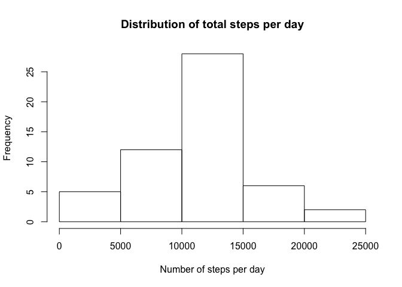

```r
##summarize is a  dplyr tool for grouping (by date) and aggregating steps
res<-summarize(group_by(df1,date), count=n(), tot=sum(steps))
hist(res$tot, main="Distribution of total steps per day", xlab="Number of steps per day")
```

2. Calculate and report the mean and median total number of steps taken per day

The mean number of steps taken per day is

```r
mean_stps_without_NAs=mean(res$tot)
mean_stps_without_NAs
```

```
## [1] 10766
```

The median number of steps taken per day is

```r
median_stps_without_NAs=median(res$tot)
median_stps_without_NAs
```

```
## [1] 10765
```

## What is the average daily activity pattern?

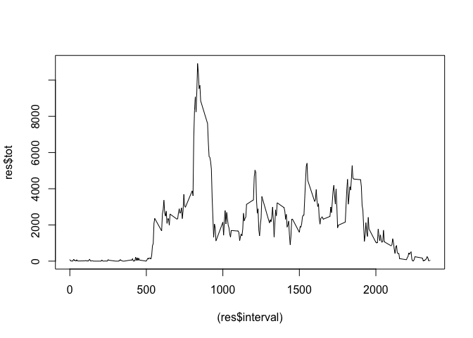

```r
res<-summarize(group_by(df1,interval), count=n(), tot=sum(steps))
plot(x=(res$interval),y=res$tot,type="l")
```

```r
##note the change in data format for interval from integer to factor.  This prevents plotting scale up to 100 instead of 60.
```

Which 5-minute interval, on average across all the days in the dataset, contains the maximum number of steps?

```r
filter (df1, steps==max(steps))
```

```
##   steps       date interval
## 1   806 2012-11-27      615
```

## Imputing missing values

```r
#Number of rows with NAs
Num_NA=nrow(df)-nrow(df1)
```

2. Devise a strategy for filling in all of the missing values in the dataset. The strategy does not need to be sophisticated. For example, you could use the mean/median for that day, or the mean for that 5-minute interval, etc.

# Take mean for that interval.

```r
res<-summarize(group_by(df1,interval),  stp_mean=sum(steps)/n())
##This builds the lookup table called res that has mean steps per interval
```

3. Create a new dataset that is equal to the original dataset but with the missing data filled in.

```r
df2<-df
df2$steps=ifelse(is.na(df2$steps),res[res$interval==df2$interval]$stp_mean,df2$steps)
```

## Runs through the new data frame and tests each step count for NA, if yes then it inserts the mean from res for that interval. If no, it leaves it alone.

4. Make a histogram of the total number of steps taken each day and Calculate and report the mean and median total number of steps taken per day. Do these values differ from the estimates from the first part of the assignment? What is the impact of imputing missing data on the estimates of the total daily number of steps?

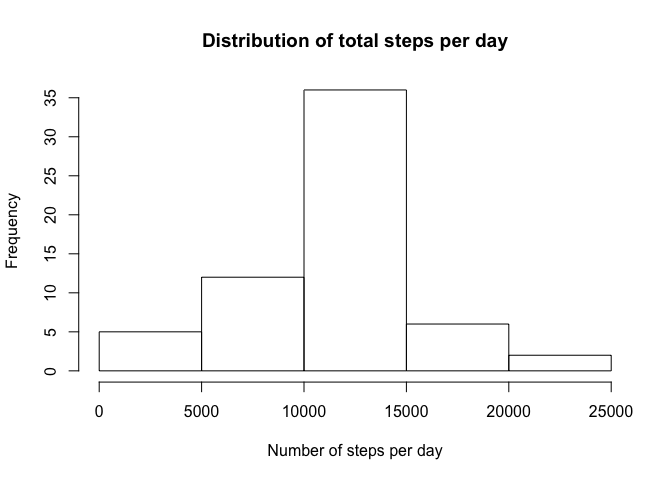

```r
res<-summarize(group_by(df2,date),  stp_total=sum(steps))
hist(res$stp_total, main="Distribution of total steps per day", xlab="Number of steps per day")
```

```r
mean_stps_imputed_NAs=mean(res$stp_total)
##Mean value of total number of steps taken per day with imputed NA values.
mean_stps_imputed_NAs
```

```
## [1] 10766
```

```r
#Imputed mean compared to mean without imputed values.
mean_stps_imputed_NAs-mean_stps_without_NAs
```

```
## [1] 0
```

```r
#Median value of total number of steps taken per day with imputed NA values
median_stps_imputed_NAs=median(res$stp_total)
median_stps_imputed_NAs
```

```
## [1] 10766
```

```r
#Imputed median compared to median without imputed values.
median_stps_imputed_NAs-median_stps_without_NAs
```

```
## [1] 1.189
```

## Are there differences in activity patterns between weekdays and weekends?

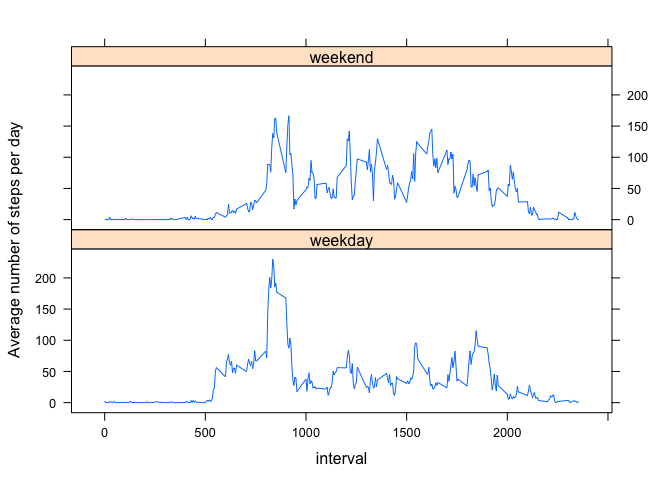

```r
#Using the weekday number function to create a new field with weekend identification
df2$weekend<-ifelse((as.POSIXlt(df2$date)$wday==0 | as.POSIXlt(df2$date)$wday==6), "weekend","weekday")
#Building a summary table by interval and weekend calculating average number of steps
res<-summarize(group_by(df2,interval,weekend), avg_stps=sum(steps)/n())
xyplot(avg_stps ~ interval | weekend, res, type='l', layout=c(1,2), ylab="Average number of steps per day")
```